# TP 3 - correction

Outils de surveillance et analyses statistiques

INTECHMER - CT3 GEM

## Données Planctons

```r
library(readr)
library(DT)
library(tidyverse)
```

```r
library(maps)
library(ggplot2)

data = read_csv("103673.csv", show_col_types = FALSE)
```

On peut représenter les points de collecte de données sur une carte à l’aide du code suivant :

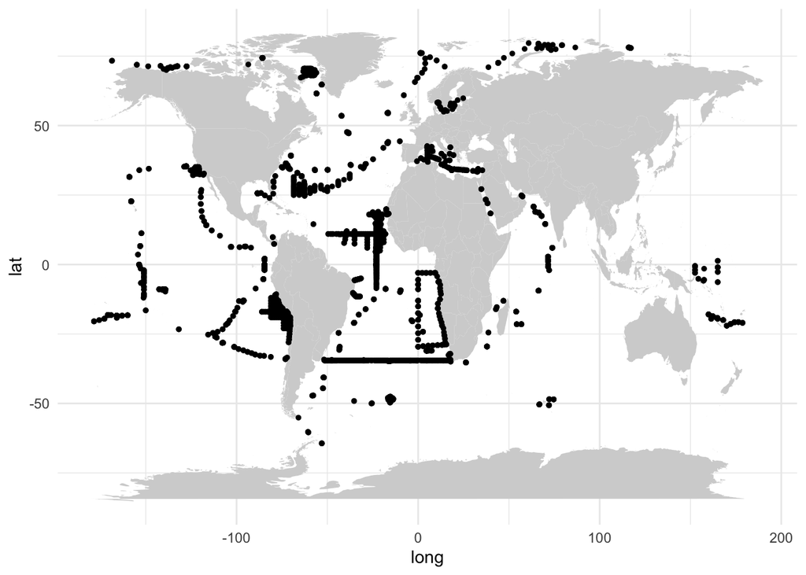

```r
ggplot() +
  geom_polygon(data = map_data("world"),
               aes(x = long, y = lat, group = group),
               fill = "lightgray") +
  geom_point(data = data, aes(x = lon, y = lat), size = 1) +
  theme_minimal()
```

## Décrire les données, en particulier de concentrations

On remarque que les concentrations sont très proches de 0, avec beaucoup de valeurs *aberrantes*/*outliers*. Il faut donc envisager de faire une transformation sur celles-ci pour pouvoir les étudier. Plusieurs possibilités :

- Transformer en variable binaire : présence / absence
- Faire des intervalles : aucun / peu / … / beaucoup
- Opérer une transformation mathématique :
  - Division par le total ou par le maximum
  - Normalisation pour que la somme en ligne soit égale à 1
  - Utiliser les rangs
  - Standardisation des variables
  - Transformation de Hellinger

$$y'_i^j = \sqrt{\frac{y_i^j}{\sum_k y_i^k}}$$

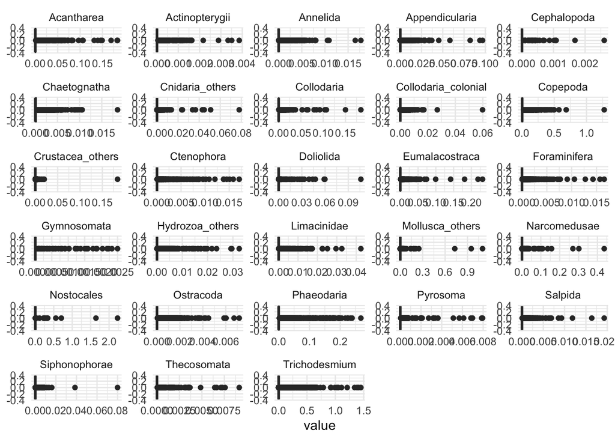

```r
data %>%
  select(Acantharea:Trichodesmium) %>%
  pivot_longer(everything()) %>%
  ggplot(aes(x = value)) +
  geom_boxplot() +
  facet_wrap(~name, scales = "free", ncol = 5) +
  theme_minimal()
```

## Effectuer une transformation de Hellinger sur les données de concentrations

On utilise donc la fonction `decostand()` du package `vegan`.

```r
library(vegan)
data_hellinger = decostand(data %>% select(Acantharea:Trichodesmium), method = "hellinger")
```

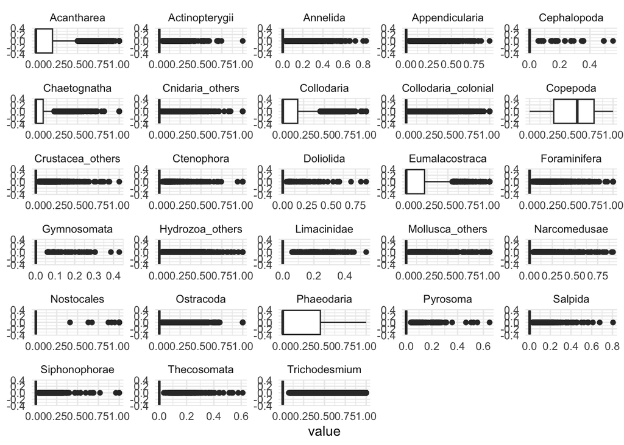

```r
data_hellinger %>%
  pivot_longer(everything()) %>%
  ggplot(aes(x = value)) +
  geom_boxplot() +
  facet_wrap(~name, scales = "free", ncol = 5) +
  theme_minimal()
```

## Faire quelques traitements sur les variables explicatives

1. Remplacer les données manquantes par la valeur moyenne de la variable
2. Transformer les variables `bulk_conc` et `snow_conc` en calculant $\log(1+x)$ (car valeurs parfois égales à 0)
3. Normaliser toutes les variables

Ces trois opérations sont réalisables en un code

```r
data_sup = data %>%
  select(temp:kd490) %>%
  replace_na(as.list(colMeans(.,na.rm=T))) %>%            # étape 1
  mutate_at(vars(snow_conc, bulk_conc), list(log1p)) %>%  # étape 2
  transmute_all(list(scale))                              # étape 3
```

## Réaliser une ACP sur les concentrations

En ajoutant les variables explicatives en variables supplémentaires (cf paramètre `quanti.sup` dans la fonction `PCA()`)

## Rechercher un nombre de classes avec une CAH (en utilisant la distance euclidienne et la méthode de *Ward*)

## Rechercher la partition optimale à l’aide de $k$-means

## Décrire les classes à partir des données de concentrations

- Représenter la partition sur le plan factoriel
- Représenter les variables supplémentaires

## Représenter la partition sur une carte